# FPP - Ch. 6 Exercises

##### Time Series Decomposition

##### Dan Hong | dnaeye@gmail.com

The following are my answers to the exercises in the excellent book [Forecasting: Principles & Practice](https://otexts.org/fpp2/) by Rob J Hyndman and George Athanasopoulos.

#### 1. Show that a 3 x 5 MA is equivalent to a 7-term weighted moving average with weights of 0.067, 0.133, 0.200, 0.200, 0.200, 0.133, and 0.067.

$y_{3x5} = \frac{1}{3}(Y_{t-1} + Y_t + Y_{t+1}) \ where\ Y_t = \frac{1}{5}(y_{t-2}+y_{t-1}+y_t+y_{t+1}+y_{t+2})$

Therefore, $y_{3+5} = \frac{1}{15}(y_{t-3} + 2y_{t-2} + 3y_{t-1} + 3y_t + 3y_{t+1} + 2y_{t+2} + y_{t+3})$

The weights for the 7 terms are $\frac{1}{15}$ (i.e., 0.067), $\frac{2}{15}$ (i.e., 0.133), $\frac{3}{15}$ (i.e., 0.200), $\frac{3}{15}$ (i.e., 0.200), $\frac{3}{15}$ (i.e., 0.200), $\frac{2}{15}$ (i.e., 0.133), and , $\frac{1}{15}$ (i.e., 0.067).

#### 2. The `plastics` data set consists of the monthly sales (in thousands) of product A for a plastics manufacturer for five years.

**2b.** Plot the time series of sales of product A. Can you identify seasonal fluctuations and/or a trend-cycle?

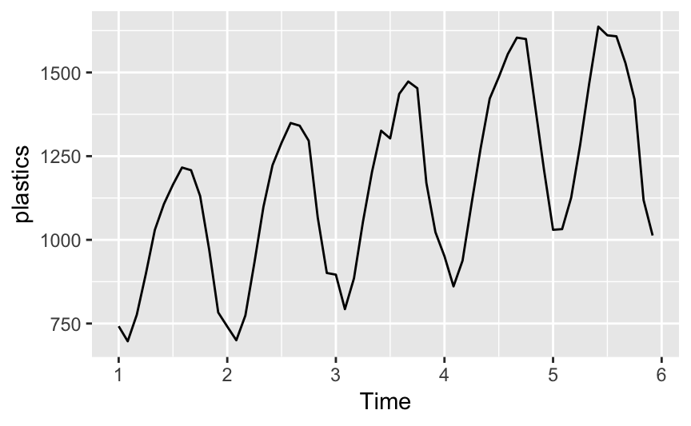

```r
autoplot(plastics)
```

There are annual seasonal fluctuations (each time period is a year) with peaks in the summer and troughs in the winter. Over the 5-year period, there is a positive trend.

**2b.** Use a classical multiplicative decomposition to calculate the trend-cycle and seasonal indices.

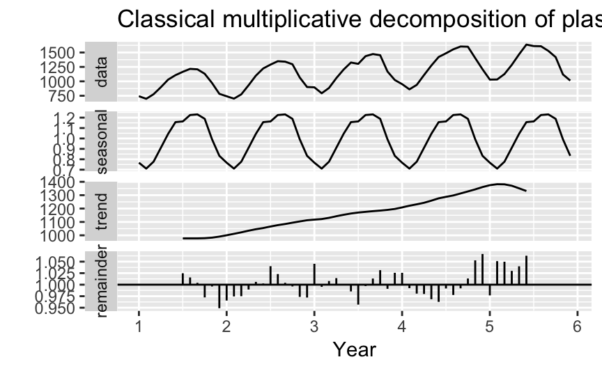

```r
plastics.dc <- decompose(plastics, type = "multiplicative")
plastics.dc %>% autoplot() + xlab("Year") + ggtitle("Classical multiplicative decomposition of plastics")
```

The seasonal indices range from 0.7 to 1.2, with the lowest in February and the highest in August. This means that sales are 0.7 x Trend (+ Remainder) in February and 1.2 x Trend (+ Remainder) in August.

**2c.** Do the results support the graphical interpretation from part a?

Yes, they do.

**2d.** Compute and plot the seasonally adjusted data.

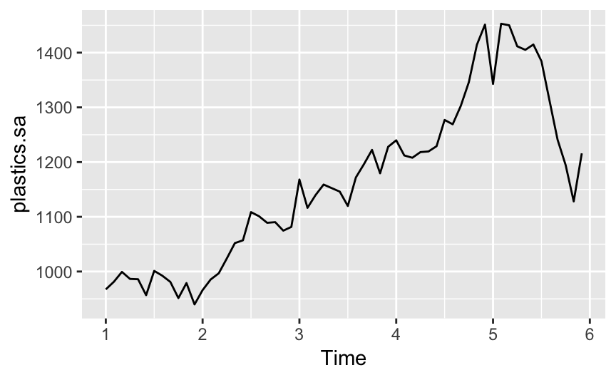

```r
plastics.sa <- plastics / plastics.dc$seasonal
autoplot(plastics.sa)
```

**2e.** Change one observation to be an outlier (e.g., add 500 to one observation), and recompute the seasonally adjusted data. What is the effect of the outlier?

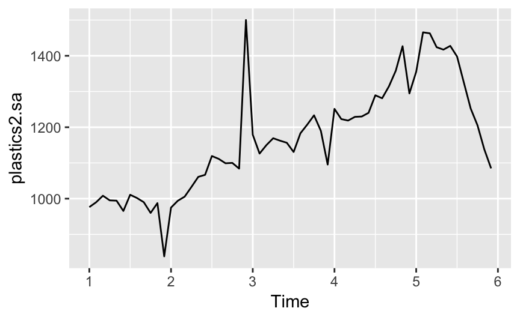

```r
plastics2 <- plastics
plastics2[24] <- plastics[24] + 500
plastics2.dc <- decompose(plastics2, type = "multiplicative")
plastics2.sa <- plastics2 / plastics2.dc$seasonal
autoplot(plastics2.sa)
```

**2f.** Does it make any difference if the outlier is near the end rather than in the middle of the time series?

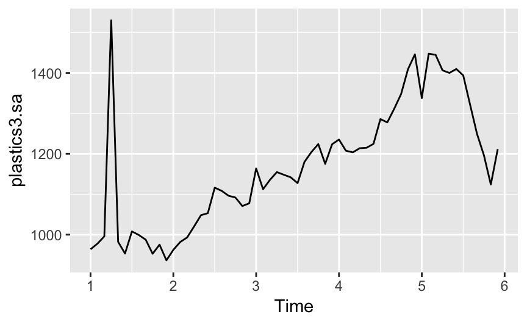

```r
plastics3 <- plastics
plastics3[4] <- plastics[4] + 500
plastics3.dc <- decompose(plastics3, type = "multiplicative")
plastics3.sa <- plastics3 / plastics3.dc$seasonal
autoplot(plastics3.sa)
```

#### 3. Recall your `retail` time series data (from Exercise 3 in Section [2.10](https://otexts.org/fpp2/graphics-exercises.html#graphics-exercises)). Decompose the series using X11. Does it reveal any outliers, or unusual features that you had not noticed previously?

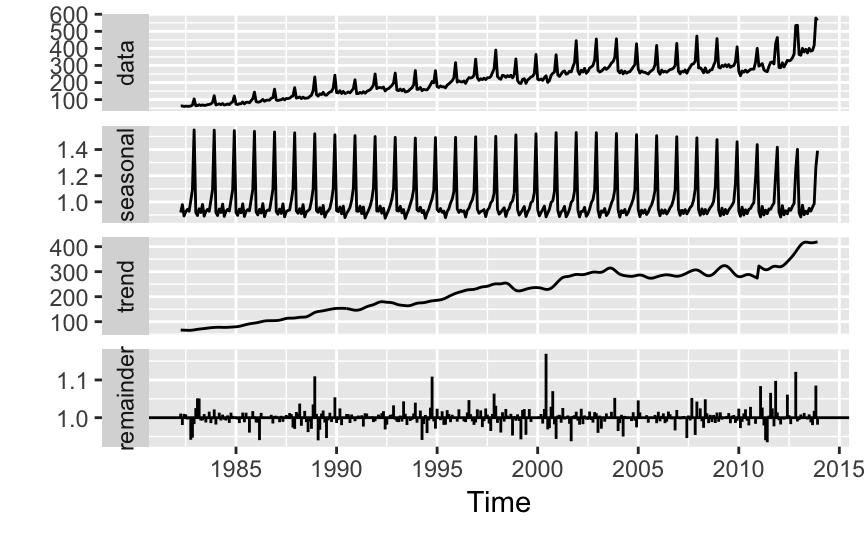

```r
retaildata <- readxl::read_excel("retail.xlsx", skip=1)
myts <- ts(retaildata[,"A3349873A"], frequency=12,
           start=c(1982,4))
library(seasonal)
retail.dc <- seas(myts, x11="")
autoplot(retail.dc)
```

The remainder plot charts noise in the data, and the largest peak was in 2000, which broke from the seasonal and trend-cycle behavior.

#### 4. Figures [6.16](https://otexts.org/fpp2/decomposition-exercises.html#fig:labour) and [6.17](https://otexts.org/fpp2/decomposition-exercises.html#fig:labour2) show the result of decomposing the number of persons in the civilian labour force in Australia each month from February 1978 to August 1995.

**4a.** Write about 3–5 sentences describing the results of the decomposition. Pay particular attention to the scales of the graphs in making your interpretation.

There is a general upward trend, indicating that the labor force is growing. Although there seems to be increasing variance in the seasonal plot, the scale indicates that the trend is relatively small when compared to the scale of the overall trend. On the other hand, the monthly plot shows varying monthly trends – some months experienced growth (e.g., July, September, December), while others experienced declines (e.g., March, August, November). The remainder plot shows that there was a huge drop in the early 1990s.

**4b.** Is the recession of 1991/1992 visible in the estimated components?

Yes, the remainder plot shows that those years were negative outliers, with drops as low as 400.

#### 5. This exercise uses the `cangas` data (monthly Canadian gas production in billions of cubic metres, January 1960 – February 2005).

**5a.** Plot the data using `autoplot()`, `ggsubseriesplot()` and `ggseasonplot()` to look at the effect of the changing seasonality over time. What do you think is causing it to change so much?

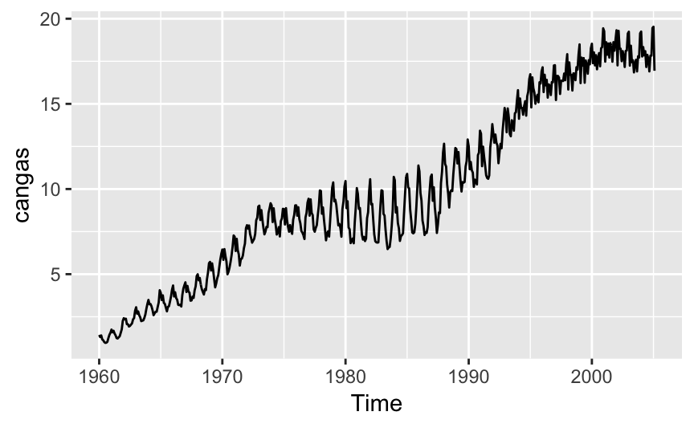

```r
autoplot(cangas)
```

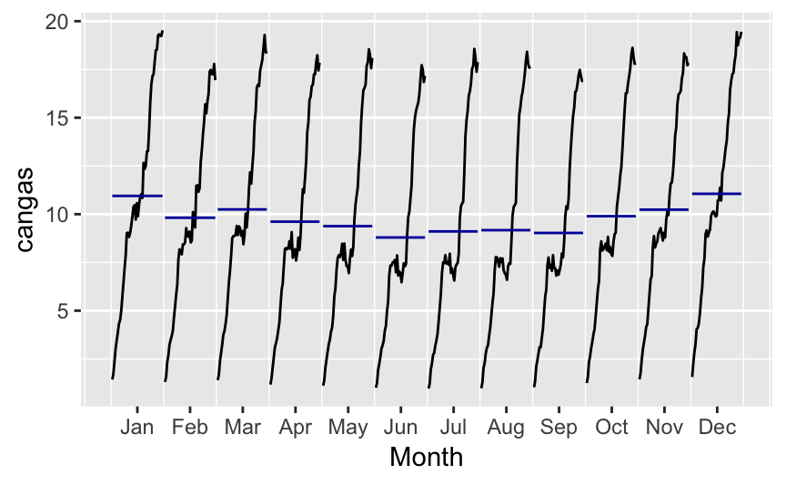

```r
ggsubseriesplot(cangas)
```

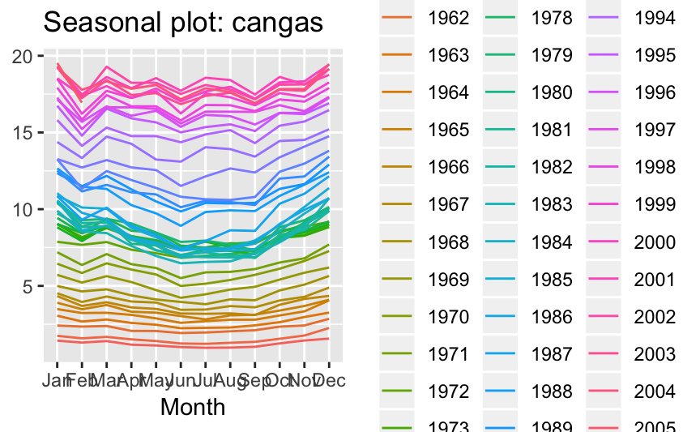

```r
ggseasonplot(cangas)
```

**5b.** Do an STL decomposition of the data. You will need to choose `s.window` to allow for the changing shape of the seasonal component.

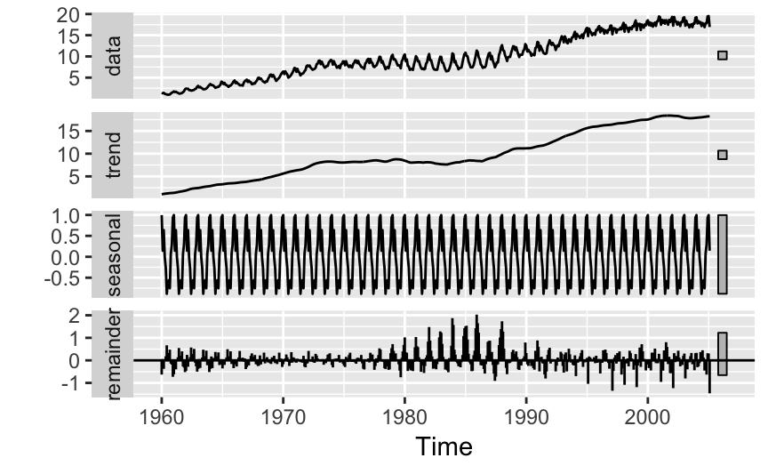

```r
cangas %>% stl(s.window = "periodic", robust=TRUE) %>% autoplot()
```

**5c.** Compare the results with those obtained using SEATS and X11. How are they different?

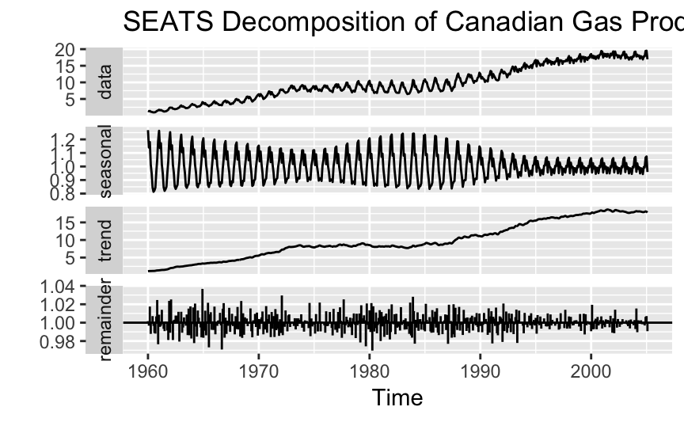

```r
library(seasonal)
cangas %>% seas() %>% autoplot() + ggtitle("SEATS Decomposition of Canadian Gas Production")
```

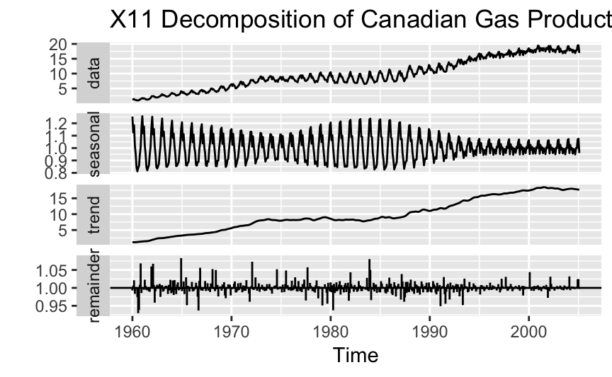

```r
cangas %>% seas(x11="") %>% autoplot() + ggtitle("X11 Decomposition of Canadian Gas Production")
```

#### 6. We will use the `bricksq` data (Australian quarterly clay brick production. 1956–1994) for this exercise.

**6a.** Use an STL decomposition to calculate the trend-cycle and seasonal indices. (Experiment with having fixed or changing seasonality.)

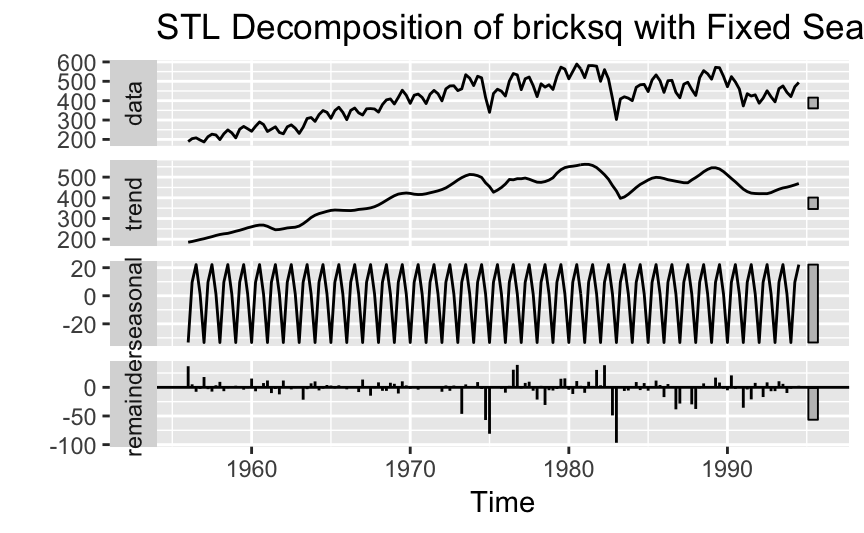

```r
bricksq %>% stl(s.window="periodic", robust=TRUE) %>% autoplot() + ggtitle("STL Decomposition of bricksq with Fixed Seasonality")
```

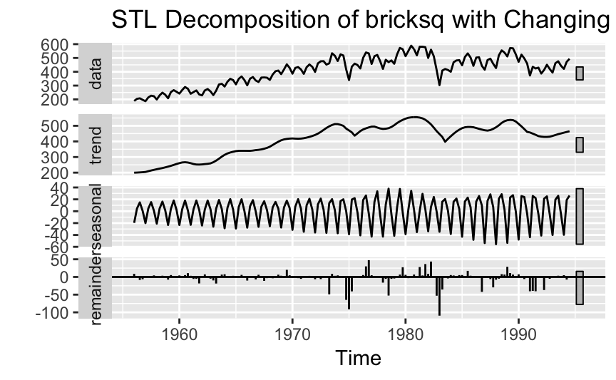

```r
bricksq %>% stl(s.window=6, robust=TRUE) %>% autoplot() + ggtitle("STL Decomposition of bricksq with Changing Seasonality")
```

**6b.** Compute and plot the seasonally adjusted data.

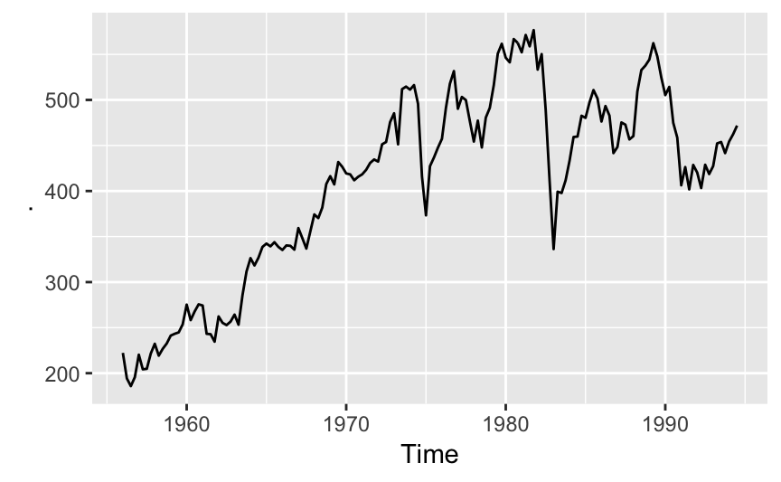

```r
bricksq %>% stl(s.window="periodic", robust=TRUE) %>% seasadj() %>% autoplot()
```

**6c.** Use a naïve method to produce forecasts of the seasonally adjusted data.

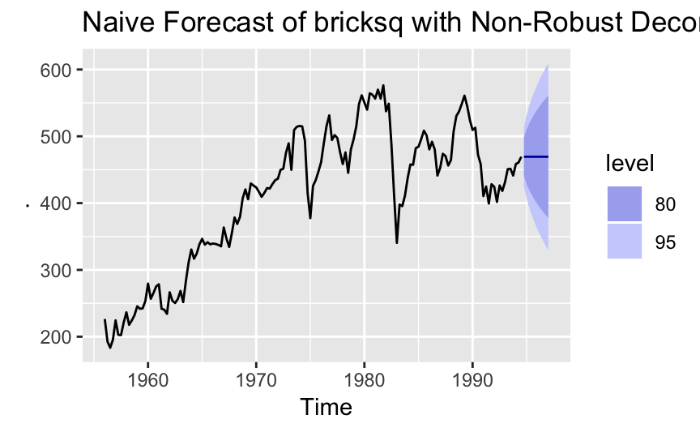

```r
bricksq.nonrobust <- stl(bricksq, s.window = "periodic", robust = FALSE)
bricksq.nonrobust %>% seasadj() %>% naive() %>% autoplot() + ggtitle("Naive Forecast of bricksq with Non-Robust Decomposition")
```

**6d.** Use `stlf()` to reseasonalise the results, giving forecasts for the original data.

```r
bricksq.rs <- stlf(bricksq, method='naive')
forecast(bricksq.rs, h=8)
```

```
        Point Forecast    Lo 80    Hi 80    Lo 95
1994 Q4       465.7338 440.1878 491.2798 426.6645
1995 Q1       424.6739 388.5464 460.8014 369.4217
1995 Q2       483.9926 439.7456 528.2395 416.3227
1995 Q3       494.0000 442.9080 545.0920 415.8615
1995 Q4       465.7338 408.6112 522.8564 378.3723
1996 Q1       424.6739 362.0992 487.2486 328.9742
1996 Q2       483.9926 416.4042 551.5809 380.6251
1996 Q3       494.0000 421.7450 566.2550 383.4955
           Hi 95
1994 Q4 504.8030
1995 Q1 479.9261
1995 Q2 551.6625
1995 Q3 572.1385
1995 Q4 553.0952
1996 Q1 520.3736
1996 Q2 587.3600
1996 Q3 604.5045
```

**6e.** Do the residuals look uncorrelated?

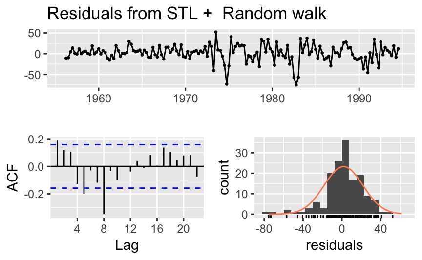

```r
checkresiduals(bricksq.rs)
```

**6f.** Repeat with a robust STL decomposition. Does it make much difference?

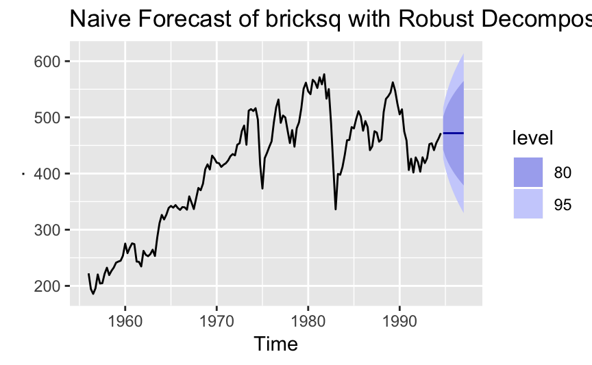

```r
bricksq.robust <- stl(bricksq, s.window="periodic", robust=TRUE)
bricksq.robust %>% seasadj() %>% naive() %>% autoplot() + ggtitle("Naive Forecast of bricksq with Robust Decomposition")
```

The plots appear to be very similar. To verify that they are similar:

```r
naive(seasadj(bricksq.robust))$mean
```

```
        Qtr1    Qtr2    Qtr3    Qtr4
1994                         471.811
1995 471.811 471.811 471.811 471.811
1996 471.811 471.811 471.811 471.811
1997 471.811
```

```r
naive(seasadj(bricksq.nonrobust))$mean
```

```
         Qtr1     Qtr2     Qtr3     Qtr4
1994                            469.4082
1995 469.4082 469.4082 469.4082 469.4082
1996 469.4082 469.4082 469.4082 469.4082
1997 469.4082
```

The difference between the two forecast methods is 2.402805. In other words, the robust forecast is just 0.51% larger than the non-robust method.

**6g.** Compare forecasts from `stlf()` with those from `snaive()`, using a test set comprising the last 2 years of data. Which is better?

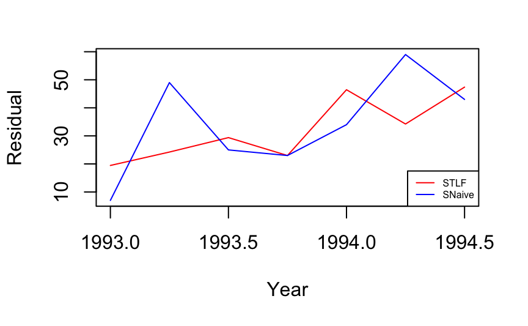

```r
bricks.train <- window(bricksq, end=c(1992,4))
bricks.test <- window(bricksq, start=c(1993,1))
bricks.stlf <- stlf(bricks.train)
bricks.snaive <- snaive(bricks.train)
fcast.stlf <- forecast(bricks.stlf, h=7)
fcast.snaive <- forecast(bricks.snaive, h=7)
res.stlf <- as.numeric(bricks.test) - fcast.stlf$mean
res.snaive <- as.numeric(bricks.test) - fcast.snaive$mean
ts.plot(res.stlf, res.snaive, gpars = list(xlab="Year", ylab="Residual", col=c("red","blue")))
legend("bottomright", legend=c("STLF","SNaive"), col=c("red","blue"), cex=0.5, lty=1)
```

Overall, the `stlf` method produced better forecasts (i.e., smaller residuals with actual test data): a mean residual of 32.022682 vs. that of 34.2857143 for `snaive`, an improvement of 6.6%.

#### 7. Use `stlf()` to produce forecasts of the `writing` series with either `method='naive'` or `method='rwdrift'`, whichever is most appropriate. Use the `lambda` argument if you think a Box-Cox transformation is required.

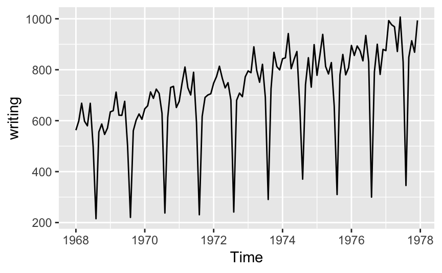

```r
autoplot(writing)
```

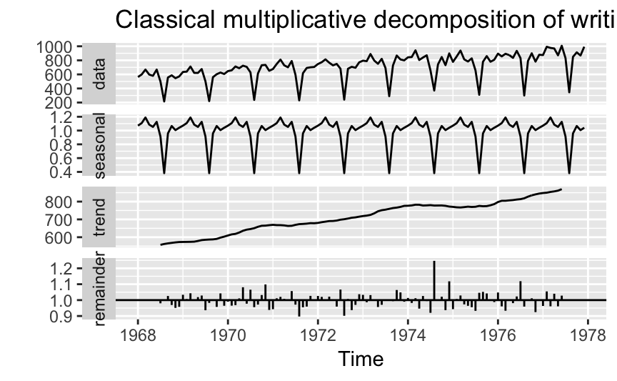

```r
writing.dc <- decompose(writing, type = "multiplicative")
writing.dc %>% autoplot() + ggtitle("Classical multiplicative decomposition of writing dataset")
```

The seasonal pattern looks very stable, but just to verify, we should run the automated Box-Cox lambda function.

```r
bcl <- BoxCox.lambda(writing)
bcl
```

```
[1] 0.1557392
```

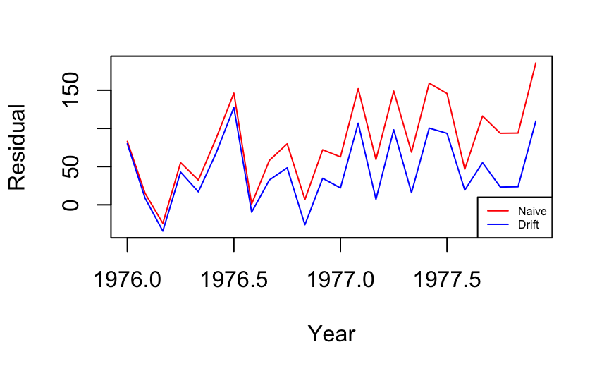

```r
writing.train <- window(writing, end=c(1975,12))
writing.test <- window(writing, start=c(1976,1))
writing.naive <- stlf(writing.train, method='naive', lambda=bcl)
fcast.naive <- forecast(writing.naive, h=24)
writing.drift <- stlf(writing.train, method='rwdrift', lambda=bcl)
fcast.drift <- forecast(writing.drift, h=24)
writing.res.naive <- as.numeric(writing.test) - fcast.naive$mean
writing.res.drift <- as.numeric(writing.test) - fcast.drift$mean
ts.plot(writing.res.naive, writing.res.drift, gpars = list(xlab="Year", ylab="Residual", col=c("red","blue")))
legend("bottomright", legend=c("Naive","Drift"), col=c("red","blue"), cex=0.5, lty=1)
```

```r
abs(mean(writing.res.naive))
```

```
[1] 81.04883
```

```r
abs(mean(writing.res.drift))
```

```
[1] 44.32244
```

Both methods performed similarly, but the `rwdrift` method performed 45.31% better.

#### 8. Use `stlf()` to produce forecasts of the `fancy` series with either `method='naive'` or `method='rwdrift'`, whichever is most appropriate. Use the `lambda` argument if you think a Box-Cox transformation is required.

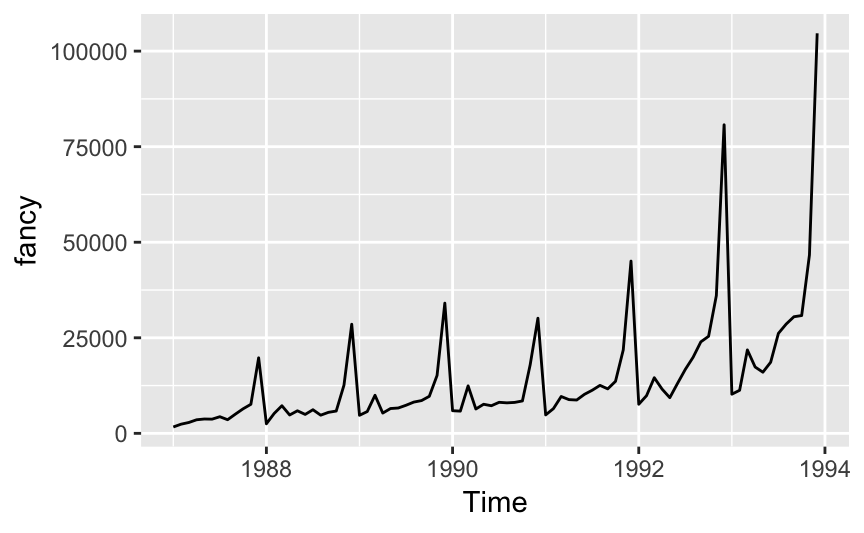

```r
autoplot(fancy)
```

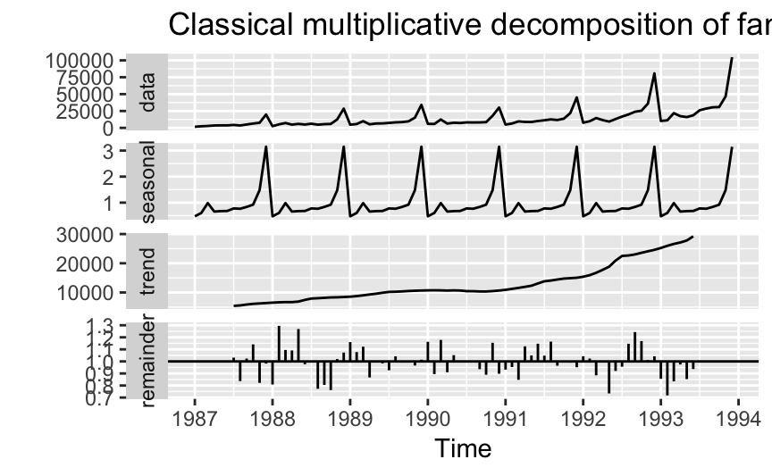

```r
fancy.dc <- decompose(fancy, type = "multiplicative")
fancy.dc %>% autoplot() + ggtitle("Classical multiplicative decomposition of fancy dataset")
```

The seasonal variation appears stable, but we should validate this by running the automated Box-Cox lambda function.

```r
bcl <- BoxCox.lambda(fancy)
bcl
```

```
[1] 0.002127317
```

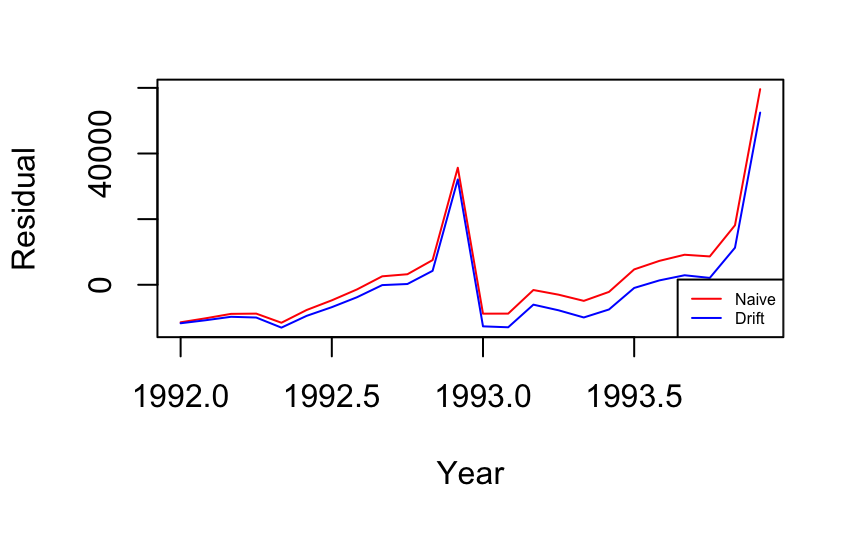

```r
fancy.train <- window(fancy, end=c(1991,12))
fancy.test <- window(fancy, start=c(1992,1))
fancy.naive <- stlf(fancy.train, method='naive')
fcast.naive <- forecast(fancy.naive, h=24)
fancy.drift <- stlf(fancy.train, method='rwdrift')
fcast.drift <- forecast(fancy.drift, h=24)
fancy.res.naive <- as.numeric(fancy.test) - fcast.naive$mean
fancy.res.drift <- as.numeric(fancy.test) - fcast.drift$mean
ts.plot(fancy.res.naive, fancy.res.drift, gpars = list(xlab="Year", ylab="Residual", col=c("red","blue")))
legend("bottomright", legend=c("Naive","Drift"), col=c("red","blue"), cex=0.5, lty=1)
```

```r
abs(mean(fancy.res.naive))
```

```
[1] 2601.172
```

```r
abs(mean(fancy.res.drift))
```

```
[1] 1117.606
```

Both methods performed similarly, but the `rwdrift` method performed 57.03% better.